# Getting Started with Geospatial Data

Last Updated 2023-02-28

This week we are beginning to work with the *sf* package, which has emerged as the clear successor to the older *sp* package. **Note:** we are not even talking about *sp* objects because they are on the way out and it would only muddy the proverbial waters. Here are convenient links to this week’s assigned readings:

- [Simple Features for R](https://r-spatial.github.io/sf/articles/sf1.html)
- [Maps](https://ggplot2-book.org/maps.html)
- [Manipulating Simple Features](https://r-spatial.github.io/sf/articles/sf4.html)

We will briefly demonstrate some of the fucntionality you read about for today using a famailiar dataset with an emphasis on bringing in the geospatial component. Accompanying this document in the **./data/** folder, you will find a .csv file called “Participatory_Budgeting_Projects.csv”. This file was taken from the New York City open data portal and more information about its contents can be [found here](https://data.cityofnewyork.us/City-Government/Participatory-Budgeting-Projects/wwhr-5ven). You can see that this dataset was created in 2017 and last updated in early 2020.

[figure not shown]

Take a few moments to re-acquaint yourself with the dataset by scrolling down the page and viewing the “Columns in this Dataset” and “Table Preview” sections in particular. Note that there are 20 columns or attributes in the dataset.

```r
nyc_ppb <- read_delim("./data/Participatory_Budgeting_Projects.csv", delim = ";")

# Use the dplyr::filter function to limit the data to 2017 and remove entries
# without cost information...
nyc_ppb_2017 <- nyc_ppb %>%
  filter(`Vote Year` == 2017) %>%
  filter(!is.na(Cost))

# Inspect the dimensions and structure of the resulting object...
dim(nyc_ppb_2017)
```

```
## [1] 383  20
```

```r
str(nyc_ppb_2017)
```

```
## spec_tbl_df [383 × 20] (S3: spec_tbl_df/tbl_df/tbl/data.frame)
##  $ Vote Year       : num [1:383] 2017 2017 2017 2017 2017 ...
##  $ Council District: chr [1:383] "44" "47" "3" "3" ...
##  $ Category        : chr [1:383] "Youth" "Parks & Recreation" "Parks & Recreation" "Education" ...
##  $ Project Number  : num [1:383] 3 7 1 3 2 11 12 5 4 7 ...
##  $ Title           : chr [1:383] "STEMLab for Brooklyn School of Inquiry" "Surf Playground" "New Park in Hell's Kitchen" "P.S. 111 Air Conditioning for the Library" ...
##  $ Description     : chr [1:383] NA "Upgrades to Surf Playground." "Funds will go towards transforming an empty lot into a new public park for the people of Hell's Kitchen. " "Project will provide air conditioning for the library, which is used as a summer school site for hundreds of students." .…
##  $ Address         : chr [1:383] NA "Surf Avenue & West 27th Street" "10th Avenue between 48th and 49th Streets" "440 West 53rd Street" ...
##  $ Votes           : num [1:383] 2113 725 1405 1323 1358 ...
##  $ Winner          : num [1:383] 1 0 1 1 1 0 0 0 1 0 ...
##  $ Cost            : num [1:383] 500000 500000 200000 150000 125000 575000 450000 144000 500000 176000 ...
##  $ BP Funding      : num [1:383] NA NA NA NA NA NA NA NA NA NA ...
##  $ Borough Code    : num [1:383] 3 3 1 1 1 1 1 1 1 1 ...
##  $ Latitude        : num [1:383] NA 40.6 40.8 40.8 40.7 ...
##  $ Longitude       : num [1:383] NA -74 -74 -74 -74 ...
##  $ Postcode        : num [1:383] NA NA NA 10019 NA ...
##  $ Community Board : chr [1:383] " " NA " " "4" ...
##  $ Census Tract    : num [1:383] NA NA NA 133 NA NA NA 83 NA NA ...
##  $ BIN             : num [1:383] NA NA NA 1026740 NA ...
##  $ BBL             : num [1:383] NA NA NA 1.01e+09 NA ...
##  $ NTA             : chr [1:383] NA NA NA "Clinton                                                                    " ...
##  - attr(*, "spec")=
##   .. cols(
##   ..   `Vote Year` = col_double(),
##   ..   `Council District` = col_character(),
##   ..   Category = col_character(),
##   ..   `Project Number` = col_double(),
##   ..   Title = col_character(),
##   ..   Description = col_character(),
##   ..   Address = col_character(),
##   ..   Votes = col_number(),
##   ..   Winner = col_double(),
##   ..   Cost = col_number(),
##   ..   `BP Funding` = col_double(),
##   ..   `Borough Code` = col_double(),
##   ..   Latitude = col_double(),
##   ..   Longitude = col_double(),
##   ..   Postcode = col_double(),
##   ..   `Community Board` = col_character(),
##   ..   `Census Tract` = col_number(),
##   ..   BIN = col_double(),
##   ..   BBL = col_double(),
##   ..   NTA = col_character()
##   .. )
##  - attr(*, "problems")=<externalptr>
```

Awesome, 😮 we now have the participatory budgeting data, but if we want to map it, we need a geospatial data layer that aligns with one of the attributes. Let’s pull down this layer with NYC [city council district boundaries](https://data.cityofnewyork.us/City-Government/City-Council-Districts/yusd-j4xi). These are available in a variety of formats:

[figure not shown]

```r
# Downloading the shapefile version is a bit of a hassle...
# First we download it...
download.file(url = "https://data.cityofnewyork.us/api/geospatial/yusd-j4xi?method=export&format=Shapefile",
              destfile = "./data/nyc_council.zip",
              mode = "wb")

# Then we unzip it...
unzip(zipfile = "./data/nyc_council.zip",
      exdir = "./data/nyc_council",
      overwrite = TRUE)

# Then we read it into an sf object...
city_council_shp <- st_read("./data/nyc_council")
class(city_council_shp)
```

```
## [1] "sf"         "data.frame"
```

```r
# On the other hand, grabbing the GeoJSON version is simpler and is
# generally the recommended approach...
city_council <- st_read("https://data.cityofnewyork.us/api/geospatial/yusd-j4xi?method=export&format=GeoJSON")
class(city_council)
```

```
## [1] "sf"         "data.frame"
```

As you read, we can use the base R `plot` function to visualize *sf* objects, but we have to specify which attribute we want, so using `ggplot2::geom_sf` is less onerous 🐔

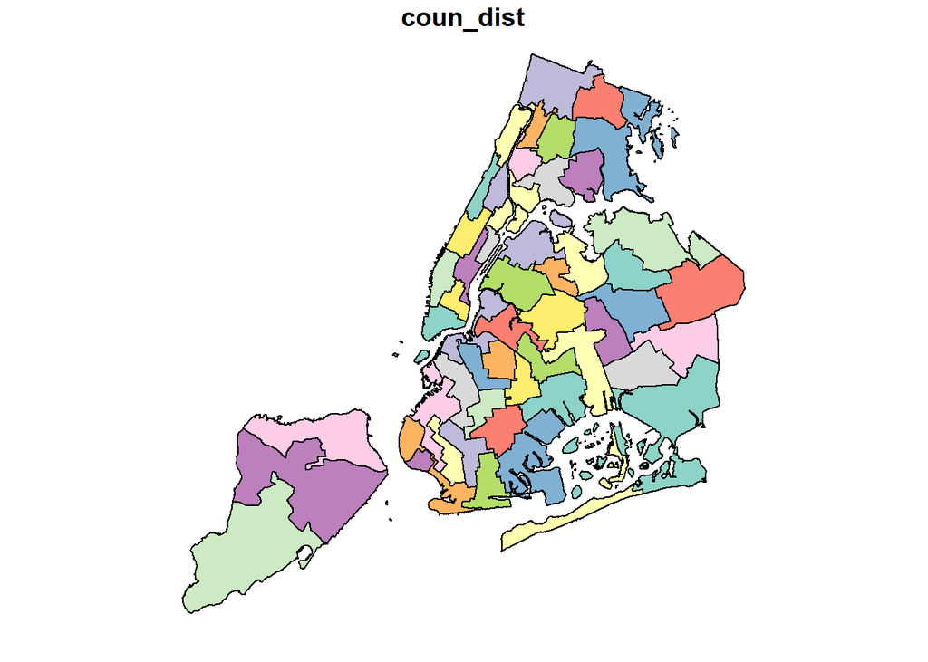

```r
# Using base R...
plot(city_council["coun_dist"])
```

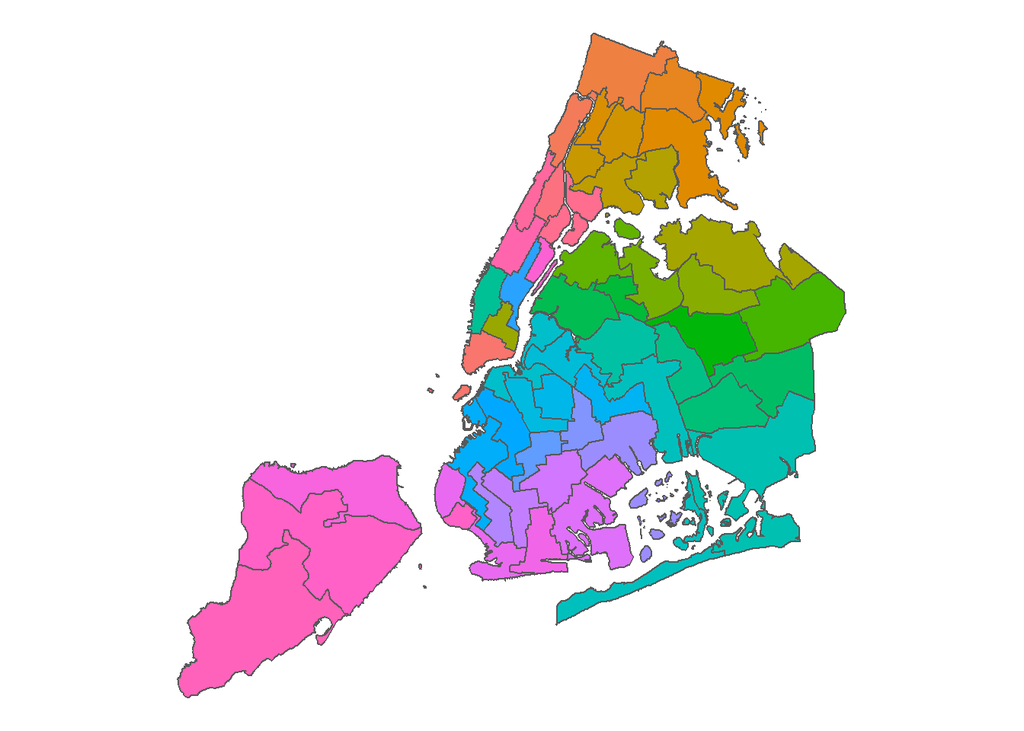

```r
# Using ggplot2...
ggplot(data = city_council, aes(fill=coun_dist)) +
  geom_sf() +
  theme_void() + theme(legend.position="none")
```

In the above code chunk, we use the `geom_sf` function to visualize the polygons that represent city council districts. Because the *coun_dist* attribute is inside the `aes` function (i.e., the [aesthetic mappings](https://r4ds.had.co.nz/data-visualisation.html#aesthetic-mappings) that specify which data attributes should be represented by which design elements of the map or chart we are creating), it gets a legend by default. However, we have set the **legend.position** argument of the `ggplot2::theme` function to “none” in order to suppress it.

Now let’s link the tabular data to the polygon layer for cryin’ out loud… 😫

```r
# First, sum the cost of winning proposals by city council district
nyc_ppb_2017_wins <- nyc_ppb_2017 %>%
  filter(Winner == 1) %>%
  group_by(`Council District`) %>%
  mutate(TotalCost = sum(Cost),
         TotalNum = n()) %>%
  summarise(`Council District`, TotalCost, TotalNum) %>%
  distinct()
```

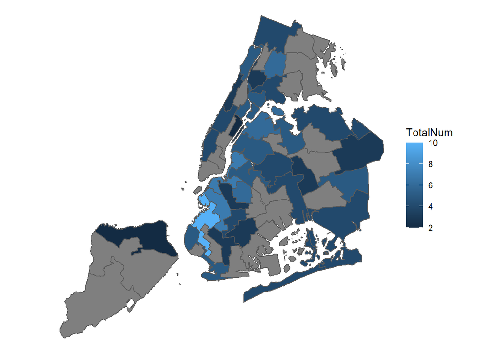

```r
# Use the dplyr::left_join function  to link the tabular participatory
# budgeting data to the council district boundaries so we can map it...
nyc_ppb_2017_wins_by_district <- left_join(city_council, nyc_ppb_2017_wins,  by = c("coun_dist" = "Council District"))


# This is a nice plot, but...
ggplot(data = nyc_ppb_2017_wins_by_district, aes(fill=TotalNum)) +
  geom_sf() +
  theme_void()
```

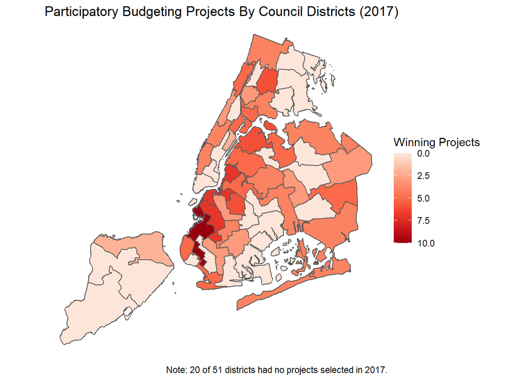

```r
# Let's replace the NA values with zero...
nyc_ppb_2017_wins_by_district_complete <- nyc_ppb_2017_wins_by_district %>%
  mutate(TotalNum = replace_na(TotalNum, 0),
         TotalCost = replace_na(TotalCost, 0))


# Then recreate it...
ggplot() +
  geom_sf(data = nyc_ppb_2017_wins_by_district_complete, aes(fill = TotalNum)) +
  scale_fill_distiller(palette = "Reds", name = "Winning Projects", trans = "reverse") +
  theme_void() +
  labs(title = "Participatory Budgeting Projects By Council Districts (2017)",
       caption = "Note: 20 of 51 districts had no projects selected in 2017.")
```

The default coordinate system for data portals built using the Socrata platform is [EPSG:4326](https://spatialreference.org/ref/epsg/4326/) so we can assume that the latitude/longitude coordinates in our data are using this (unprojected) coordinate system.

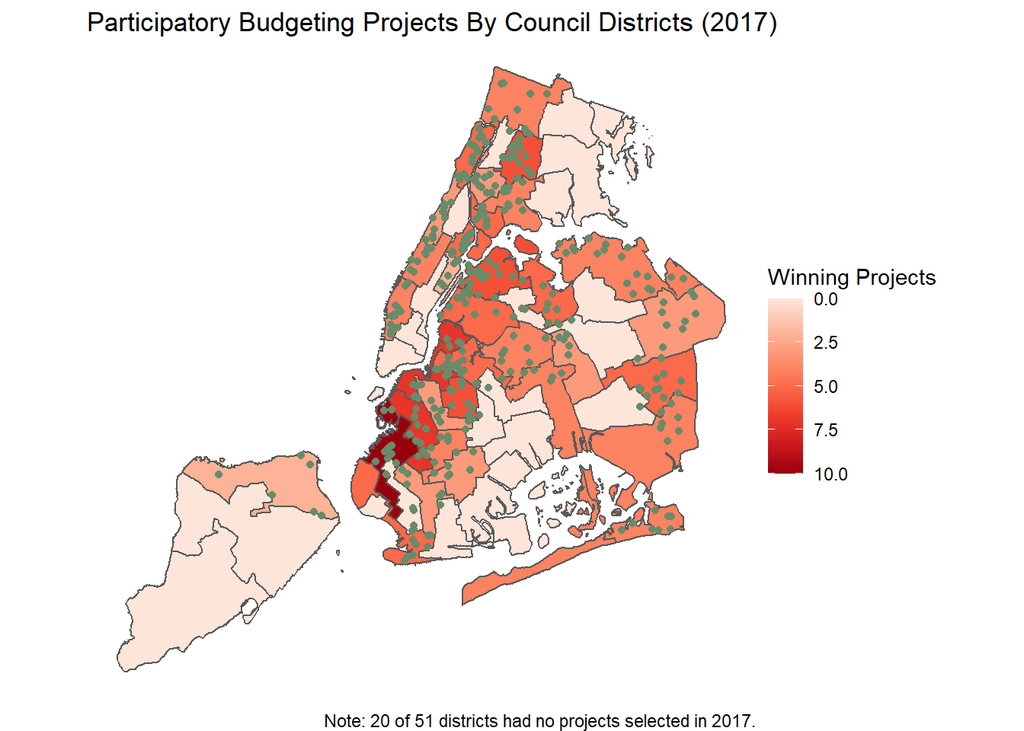

```r
# Create a point sf object...
funded_projects <- nyc_ppb_2017 %>%
  drop_na(Longitude) %>%
  st_as_sf(coords = c("Longitude", "Latitude"), crs = "EPSG:4326")


# Add it to our existing plot...
ggplot() +
  geom_sf(data = nyc_ppb_2017_wins_by_district_complete, aes(fill = TotalNum), na.rm = TRUE) +
  geom_sf(data = funded_projects, color = "darkseagreen4") +
  scale_fill_distiller(palette = "Reds", name = "Winning Projects", trans = "reverse") +
  theme_void() +
  labs(title = "Participatory Budgeting Projects By Council Districts (2017)",
       caption = "Note: 20 of 51 districts had no projects selected in 2017.")
```

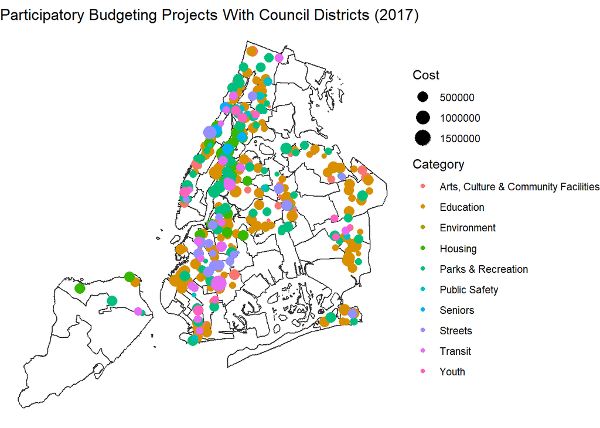

```r
# Get an initial sense of the type and cost of these projects...
ggplot() +
  geom_sf(data = nyc_ppb_2017_wins_by_district, color = "grey20", fill = NA) +
  geom_sf(data = funded_projects, aes(color = Category, size = Cost)) +
  theme_void() +
  labs(title = "Participatory Budgeting Projects With Council Districts (2017)")
```

We use the `st_crs` function to display the coordinate system for a given *sf* object but we use the `st_transform` function to **change the coordinate system** of a given *sf* object.

The code chunk below demonstrates how to create a brand new point *sf* object from a single pair of coordinates. These lat/lon coordinates represent the location of New York City’s city hall building. Make sure you understand it, then proceed…

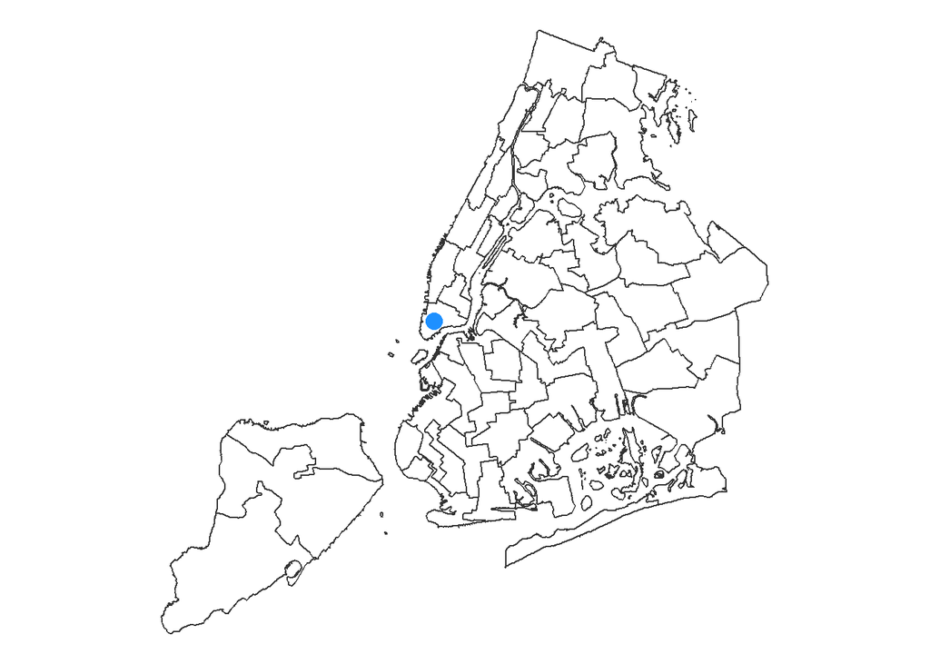

```r
ch_geometry = st_sfc(st_point(c(-74.00605901347289, 40.71308342109256)))

city_hall <- st_sf(Name = "City Hall", ch_geometry, crs = "EPSG:4326")


# Place it on the map for context...
ggplot() +
  geom_sf(data = nyc_ppb_2017_wins_by_district, color = "grey20", fill = NA) +
  geom_sf(data = city_hall, color = "dodgerblue", size = 4, shape = 19) +
  theme_void()
```

### **Your Turn**

[figure not shown]

You have reached the end! 🐦